# trade of asia

Firas

11/27/2021

## Analisa Kebutuhan di Asia

Import dan Eksport merupakan suatu kegiatan jual beli dimana kegitan tersebut dilakukan dari satu negara terhadap negara lain untuk memenuhi kebutuhan pasar yang dirasa kurangnya ketersediaan barang dalam suatu negara tersebut. Laporan ini merupakan hasil dari analisa yang penulis lakukan terkait dengan kegiatan eksport dan import yang ada di asia. Komoditas dari kegiatan jual beli ini merupakan barang jual-beli yang dihasilkan dari laut. Disini penulis anak menampilkan langkah dan hasil yang ditempuh untuk melakukan analisa. Data sets yang digunakan penulis merupakan public data sets yang di dapatkan dari http://kaggle.com.

### Import Data

Langkah awal yang harus dilakukan ketika akan melakukan analisis dengan menggunakan ‘R’ adalah melakukan pengambilan data yang akan diolah. penulis menggunakan ‘Syntax’ sebagai berikut untuk melakukan pengambilan data dari file CSV yang berjumlah 2 buah yaitu Asia_Value.csv dan Asia_Quantity.

```r
Asian_value <- read.csv("Asia_Value.csv")
Asian_quantity <- read.csv("Asia_Quantity.csv")
```

### Show and Clean the Data sets

Dibawah ini merupakan bentuk dari data sets yang digunakan. Dengan fungsi ‘head()’ akan menampilkan hanya 6 baris pertama dari data sets yang digunakan.

```r
head(Asian_value)
```

```
##     Land.Area Trade.flow   Commodity X2000 S_2000 X2001 S_2001 X2002 S_2002
## 1 Afghanistan     Import        Fish     0      .     0      .     0      .
## 2     Armenia     Export Crustaceans    81           15         1665
## 3     Armenia     Export        Fish    14          143           42
## 4     Armenia     Import Crustaceans    10            0      -     2
## 5     Armenia     Import        Fish   661         1307          767
## 6  Azerbaijan     Export        Fish  2101          798         1148
##   X2003 S_2003 X2004 S_2004 X2005 S_2005 X2006 S_2006 X2007 S_2007 X2008 S_2008
## 1     0      .     0      .     0      .     0      .     0      .     0      .
## 2  3079         2752         2705         3992         4152         4720
## 3    92          183          475          567          531          678
## 4     9            2            1            3           22          126
## 5   603          597         3001         2310         2695         7362
## 6  4083         4638         7252          659         5851         5601
##   X2009 S_2009 X2010 S_2010 X2011 S_2011 X2012 S_2012 X2013 S_2013 X2014 S_2014
## 1     0      .     9            0      -     0      -     0      -     0      -
## 2  3403         3785         5984         7510        15703        13523      F
## 3   124         3898        10189        14977        17897        17906
## 4   173          185          112          248          351          219
## 5  6894         4761         6436         6061         5457         5812
## 6  5954         1021          226            0      -    24            0      -
##   X2015 S_2015
## 1     0      -
## 2  3355
## 3 11603
## 4   278
## 5  5084
## 6    23
```

```r
head(Asian_quantity)
```

```
##     Land.Area Trade.flow   Commodity X2000 S_2000 X2001 S_2001 X2002 S_2002
## 1 Afghanistan     Import        Fish     0      .     0      .     0      .
## 2     Armenia     Export Crustaceans    20            5          391
## 3     Armenia     Export        Fish    11           97           53
## 4     Armenia     Import Crustaceans     4            0      -     1
## 5     Armenia     Import        Fish   799         1080         1239
## 6  Azerbaijan     Export        Fish  1738          364           59
##   X2003 S_2003 X2004 S_2004 X2005 S_2005 X2006 S_2006 X2007 S_2007 X2008 S_2008
## 1     0      .     0      .     0      .     0      .     0      .     0      .
## 2   761          804          716          968          797          906
## 3    28           68          131           80           70           81
## 4     4            0      -     0      -     1            0      0     8
## 5   870          833         6729         1791         1739         3436
## 6   336         2300         3055          538          856          517
##   X2009 S_2009 X2010 S_2010 X2011 S_2011 X2012 S_2012 X2013 S_2013 X2014 S_2014
## 1     0      .     9            0      -     0      -     0      -     0      -
## 2   639          898         1346         2087         4618         4009      F
## 3    23          432         1313         1844         2269         1733      F
## 4    14           14           11           34           47           25
## 5  3798         2595         3658         3539         2946         2604
## 6   493          246          270            0      -    32            0      -
##   X2015 S_2015
## 1     0      -
## 2  2786
## 3  1649
## 4    49
## 5  2578
## 6     0      -
```

Selanjutnya penulis menampilkan nama kolom dari tabel yang digunakan menggunakan fungsi ‘colnames()’. Pemanggilan nama kolom ini bertujuan untuk mempermudah pengenalan dari data yang digunakan dan untuk memproyeksikan analisa yag dilakukan terhadap data yang digunakan.

```r
colnames(Asian_quantity)
```

```
##  [1] "Land.Area"  "Trade.flow" "Commodity"  "X2000"      "S_2000"
##  [6] "X2001"      "S_2001"     "X2002"      "S_2002"     "X2003"
## [11] "S_2003"     "X2004"      "S_2004"     "X2005"      "S_2005"
## [16] "X2006"      "S_2006"     "X2007"      "S_2007"     "X2008"
## [21] "S_2008"     "X2009"      "S_2009"     "X2010"      "S_2010"
## [26] "X2011"      "S_2011"     "X2012"      "S_2012"     "X2013"
## [31] "S_2013"     "X2014"      "S_2014"     "X2015"      "S_2015"
```

```r
colnames(Asian_value)
```

```
##  [1] "Land.Area"  "Trade.flow" "Commodity"  "X2000"      "S_2000"
##  [6] "X2001"      "S_2001"     "X2002"      "S_2002"     "X2003"
## [11] "S_2003"     "X2004"      "S_2004"     "X2005"      "S_2005"
## [16] "X2006"      "S_2006"     "X2007"      "S_2007"     "X2008"
## [21] "S_2008"     "X2009"      "S_2009"     "X2010"      "S_2010"
## [26] "X2011"      "S_2011"     "X2012"      "S_2012"     "X2013"
## [31] "S_2013"     "X2014"      "S_2014"     "X2015"      "S_2015"
```

Nama kolom yang digunakan dari data sets telah didapatkan tahap selanjutnya penulis menggunakan fungsi ‘skim_without_chart()’ untuk mengenali bentuk dari data yang digunakan seperti tipe data dari tiap kolom data sets. informasi lain yang ditampilkan merupakan min, max, missing dan empty data dari tiap baris data sets yang digunakan.

```r
skim_without_charts(Asian_value)
```

Data summary

| Name | Asian_value |
| --- | --- |
| Number of rows | 192 |
| Number of columns | 35 |
| _______________________ |  |
| Column type frequency: |  |
| character | 19 |
| numeric | 16 |
| ________________________ |  |
| Group variables | None |

**Variable type: character**

| skim_variable | n_missing | complete_rate | min | max | empty | n_unique | whitespace |
| --- | --- | --- | --- | --- | --- | --- | --- |
| Land.Area | 0 | 1 | 4 | 24 | 0 | 51 | 0 |
| Trade.flow | 0 | 1 | 6 | 6 | 0 | 2 | 0 |
| Commodity | 0 | 1 | 4 | 11 | 0 | 2 | 0 |
| S_2000 | 0 | 1 | 0 | 1 | 130 | 4 | 0 |
| S_2001 | 0 | 1 | 0 | 1 | 141 | 5 | 0 |
| S_2002 | 0 | 1 | 0 | 1 | 143 | 5 | 0 |
| S_2003 | 0 | 1 | 0 | 1 | 146 | 5 | 0 |
| S_2004 | 0 | 1 | 0 | 1 | 146 | 4 | 0 |
| S_2005 | 0 | 1 | 0 | 1 | 147 | 4 | 0 |
| S_2006 | 0 | 1 | 0 | 1 | 148 | 4 | 0 |
| S_2007 | 0 | 1 | 0 | 1 | 144 | 4 | 0 |
| S_2008 | 0 | 1 | 0 | 1 | 146 | 5 | 0 |
| S_2009 | 0 | 1 | 0 | 1 | 147 | 5 | 0 |
| S_2010 | 0 | 1 | 0 | 1 | 147 | 4 | 0 |
| S_2011 | 0 | 1 | 0 | 1 | 138 | 4 | 0 |
| S_2012 | 0 | 1 | 0 | 1 | 142 | 3 | 0 |
| S_2013 | 0 | 1 | 0 | 1 | 151 | 4 | 0 |
| S_2014 | 0 | 1 | 0 | 1 | 130 | 4 | 0 |
| S_2015 | 0 | 1 | 0 | 1 | 139 | 3 | 0 |

**Variable type: numeric**

| skim_variable | n_missing | complete_rate | mean | sd | p0 | p25 | p50 | p75 | p100 |
| --- | --- | --- | --- | --- | --- | --- | --- | --- | --- |
| X2000 | 0 | 1 | 185179.2 | 777510.0 | 0 | 74.00 | 3268.0 | 49862.50 | 8666195 |
| X2001 | 0 | 1 | 177408.3 | 703233.2 | 0 | 76.50 | 3395.5 | 44623.50 | 7795565 |
| X2002 | 0 | 1 | 181517.9 | 701098.4 | 0 | 146.25 | 3509.0 | 52469.50 | 7800323 |
| X2003 | 0 | 1 | 184626.0 | 678120.5 | 0 | 162.50 | 4249.5 | 63171.00 | 7454599 |
| X2004 | 0 | 1 | 215161.2 | 797115.9 | 0 | 206.00 | 5931.0 | 59427.75 | 8704014 |
| X2005 | 0 | 1 | 230267.4 | 830026.7 | 0 | 269.25 | 6950.5 | 75417.00 | 8801198 |
| X2006 | 0 | 1 | 245858.9 | 850142.1 | 0 | 377.00 | 7382.0 | 82230.75 | 8254025 |
| X2007 | 0 | 1 | 258142.9 | 853720.7 | 0 | 317.00 | 7242.0 | 89076.25 | 7839071 |
| X2008 | 0 | 1 | 291954.6 | 975462.0 | 0 | 531.25 | 10523.0 | 110345.50 | 9266376 |
| X2009 | 0 | 1 | 277177.2 | 901753.9 | 0 | 549.25 | 10762.0 | 102545.50 | 8120696 |
| X2010 | 0 | 1 | 324988.8 | 1055613.2 | 0 | 826.50 | 12972.5 | 119136.75 | 9069369 |
| X2011 | 0 | 1 | 390308.9 | 1270368.8 | 0 | 699.50 | 14924.0 | 147902.25 | 10559977 |
| X2012 | 0 | 1 | 404412.6 | 1316436.8 | 0 | 609.75 | 15139.0 | 154513.75 | 11023982 |
| X2013 | 0 | 1 | 404389.1 | 1257552.5 | 0 | 675.00 | 17689.5 | 160448.75 | 11045046 |
| X2014 | 0 | 1 | 422373.7 | 1297570.4 | 0 | 564.00 | 19688.0 | 161649.75 | 11538511 |
| X2015 | 0 | 1 | 382106.6 | 1186739.7 | 0 | 737.00 | 20367.5 | 150040.75 | 10991570 |

```r
skim_without_charts(Asian_quantity)
```

Data summary

| Name | Asian_quantity |
| --- | --- |
| Number of rows | 190 |
| Number of columns | 35 |
| _______________________ |  |
| Column type frequency: |  |
| character | 19 |
| numeric | 16 |
| ________________________ |  |
| Group variables | None |

**Variable type: character**

| skim_variable | n_missing | complete_rate | min | max | empty | n_unique | whitespace |
| --- | --- | --- | --- | --- | --- | --- | --- |
| Land.Area | 0 | 1 | 4 | 24 | 0 | 51 | 0 |
| Trade.flow | 0 | 1 | 6 | 6 | 0 | 2 | 0 |
| Commodity | 0 | 1 | 4 | 11 | 0 | 2 | 0 |
| S_2000 | 0 | 1 | 0 | 1 | 125 | 4 | 0 |
| S_2001 | 0 | 1 | 0 | 1 | 136 | 5 | 0 |
| S_2002 | 0 | 1 | 0 | 1 | 137 | 5 | 0 |
| S_2003 | 0 | 1 | 0 | 1 | 141 | 5 | 0 |
| S_2004 | 0 | 1 | 0 | 1 | 141 | 5 | 0 |
| S_2005 | 0 | 1 | 0 | 1 | 141 | 5 | 0 |
| S_2006 | 0 | 1 | 0 | 1 | 144 | 5 | 0 |
| S_2007 | 0 | 1 | 0 | 1 | 142 | 5 | 0 |
| S_2008 | 0 | 1 | 0 | 1 | 143 | 5 | 0 |
| S_2009 | 0 | 1 | 0 | 1 | 143 | 5 | 0 |
| S_2010 | 0 | 1 | 0 | 1 | 143 | 5 | 0 |
| S_2011 | 0 | 1 | 0 | 1 | 130 | 5 | 0 |
| S_2012 | 0 | 1 | 0 | 1 | 139 | 3 | 0 |
| S_2013 | 0 | 1 | 0 | 1 | 147 | 4 | 0 |
| S_2014 | 0 | 1 | 0 | 1 | 126 | 4 | 0 |
| S_2015 | 0 | 1 | 0 | 1 | 134 | 3 | 0 |

**Variable type: numeric**

| skim_variable | n_missing | complete_rate | mean | sd | p0 | p25 | p50 | p75 | p100 |
| --- | --- | --- | --- | --- | --- | --- | --- | --- | --- |
| X2000 | 0 | 1 | 60060.03 | 208391.7 | 0 | 36.25 | 1594.5 | 24304.00 | 2125207 |
| X2001 | 0 | 1 | 65732.41 | 233991.8 | 0 | 43.75 | 1674.5 | 24531.50 | 2264241 |
| X2002 | 0 | 1 | 70867.78 | 240390.3 | 0 | 62.75 | 2227.0 | 23614.50 | 2271741 |
| X2003 | 0 | 1 | 72755.18 | 234474.2 | 0 | 98.50 | 2628.0 | 30458.50 | 1953832 |
| X2004 | 0 | 1 | 78598.38 | 255058.1 | 0 | 91.50 | 3102.5 | 31917.25 | 2061470 |
| X2005 | 0 | 1 | 83593.14 | 269363.6 | 0 | 111.00 | 3719.0 | 35934.25 | 1971499 |
| X2006 | 0 | 1 | 89267.58 | 282369.1 | 0 | 129.25 | 3292.0 | 35018.25 | 2001687 |
| X2007 | 0 | 1 | 89560.63 | 284234.4 | 0 | 138.75 | 3044.0 | 34392.50 | 2068960 |
| X2008 | 0 | 1 | 89608.55 | 282131.1 | 0 | 166.25 | 3291.0 | 34972.25 | 2038431 |
| X2009 | 0 | 1 | 90559.32 | 278824.9 | 0 | 196.50 | 3778.5 | 38198.25 | 2041639 |
| X2010 | 0 | 1 | 101803.76 | 306523.7 | 0 | 210.00 | 3535.5 | 38161.50 | 2302025 |
| X2011 | 0 | 1 | 105275.64 | 330416.4 | 0 | 251.25 | 3837.5 | 41221.00 | 2755111 |
| X2012 | 0 | 1 | 104648.98 | 323290.8 | 0 | 170.75 | 3403.5 | 40445.50 | 2678625 |
| X2013 | 0 | 1 | 105457.19 | 326643.0 | 0 | 203.25 | 4273.5 | 45186.25 | 2760685 |
| X2014 | 0 | 1 | 107386.26 | 334059.7 | 0 | 219.25 | 4417.5 | 50641.50 | 2881463 |
| X2015 | 0 | 1 | 103762.76 | 319055.5 | 0 | 180.00 | 5903.0 | 43818.00 | 2780461 |

### Perbandingan Komoditas

Dari transaksi eksport dan import yang dilakukan di berbagai negara Asia terkait komoditas hasil laut pada tabel “Asian_value” dapat ditampilkan sebagai berikut:

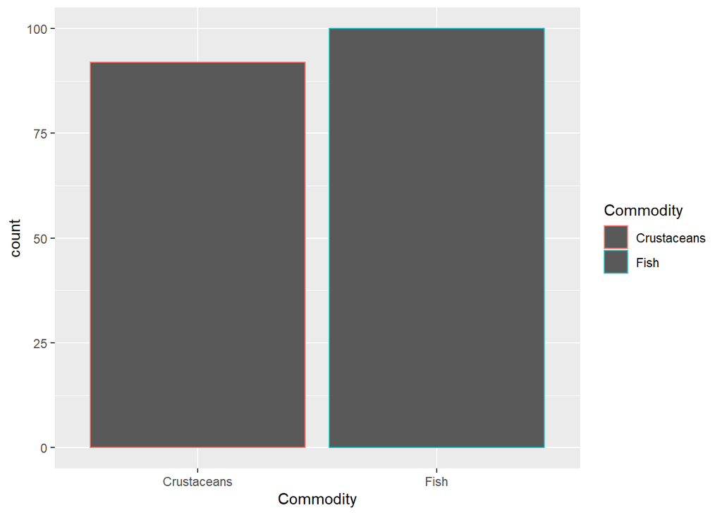

```r
ggplot(Asian_value)+
  geom_bar(mapping = aes(x=Commodity,color=Commodity,))
```

Lalu hasil dari tabel ‘Asian_quantity’ menghasilkan visualisasi sebagai berikut:

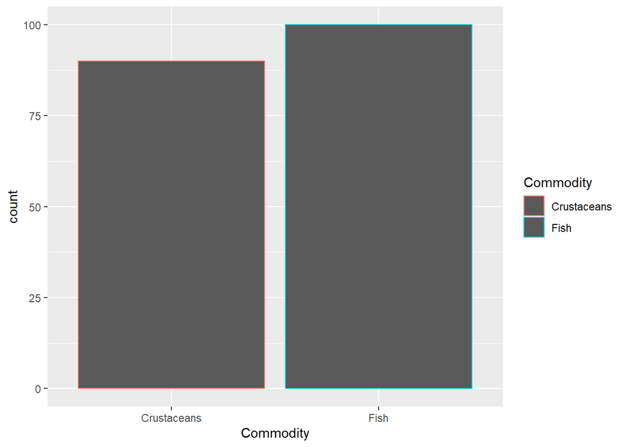

```r
ggplot(Asian_quantity)+
  geom_bar(mapping = aes(x=Commodity,color=Commodity,))
```

Hasil pada tahun 2000:

```
## # A tibble: 6 x 4
##   Land.Area   mean_tahun_2000 min_tahun_2000 max_tahun_2000
##   <chr>                 <dbl>          <int>          <int>
## 1 Afghanistan              0               0              0
## 2 Armenia                192.             10            661
## 3 Azerbaijan            1181               3           2101
## 4 Bahrain               3540.            895           8014
## 5 Bangladesh           86438             300         311879
## 6 Bhutan                   0               0              0
```

Hasil pada tahun 2001:

```
## # A tibble: 6 x 4
##   Land.Area   mean_tahun_2001 min_tahun_2001 max_tahun_2001
##   <chr>                 <dbl>          <int>          <int>
## 1 Afghanistan              0               0              0
## 2 Armenia                366.              0           1307
## 3 Azerbaijan             704.              4           1309
## 4 Bahrain               3977             851           7213
## 5 Bangladesh           90475.            194         333821
## 6 Bhutan                   0               0              0
```

Hasil pada tahun 2002:

```
## # A tibble: 6 x 4
##   Land.Area   mean_tahun_2002 min_tahun_2002 max_tahun_2002
##   <chr>                 <dbl>          <int>          <int>
## 1 Afghanistan              0               0              0
## 2 Armenia                619               2           1665
## 3 Azerbaijan            1035              14           1943
## 4 Bahrain               4986.           2758           7867
## 5 Bangladesh           77764.            565         275975
## 6 Bhutan                   0               0              0
```

Hasil pada tahun 2003:

```
## # A tibble: 6 x 4
##   Land.Area   mean_tahun_2003 min_tahun_2003 max_tahun_2003
##   <chr>                 <dbl>          <int>          <int>
## 1 Afghanistan              0               0              0
## 2 Armenia                946.              9           3079
## 3 Azerbaijan            2067               7           4083
## 4 Bahrain               4267.           1057           7217
## 5 Bangladesh           82576             166         303051
## 6 Bhutan                   0               0              0
```

Hasil pada tahun 2004:

```
## # A tibble: 6 x 4
##   Land.Area   mean_tahun_2004 min_tahun_2004 max_tahun_2004
##   <chr>                 <dbl>          <int>          <int>
## 1 Afghanistan              0               0              0
## 2 Armenia                884.              2           2752
## 3 Azerbaijan            2316.              5           4638
## 4 Bahrain               5018.           1574          10914
## 5 Bangladesh           95848            5186         345482
## 6 Bhutan                   0               0              0
```

Hasil pada tahun 2005:

```
## # A tibble: 6 x 4
##   Land.Area   mean_tahun_2005 min_tahun_2005 max_tahun_2005
##   <chr>                 <dbl>          <int>          <int>
## 1 Afghanistan              0               0              0
## 2 Armenia               1546.              1           3001
## 3 Azerbaijan            4019.             49           7252
## 4 Bahrain               5392            1940           8958
## 5 Bangladesh          158894.           1118         551840
## 6 Bhutan                 622               0           1859
```

Hasil pada tahun 2006:

```
## # A tibble: 6 x 4
##   Land.Area   mean_tahun_2006 min_tahun_2006 max_tahun_2006
##   <chr>                 <dbl>          <int>          <int>
## 1 Afghanistan              0               0              0
## 2 Armenia               1718               3           3992
## 3 Azerbaijan            1185              29           2867
## 4 Bahrain               4876.           2125           9091
## 5 Bangladesh          112548.            429         401277
## 6 Bhutan                 668               0           1997
```

Hasil pada tahun 2007:

```
## # A tibble: 6 x 4
##   Land.Area   mean_tahun_2007 min_tahun_2007 max_tahun_2007
##   <chr>                 <dbl>          <int>          <int>
## 1 Afghanistan              0               0              0
## 2 Armenia               1850              22           4152
## 3 Azerbaijan            3876              52           5851
## 4 Bahrain               5035.           1514           9050
## 5 Bangladesh          158055             272         569351
## 6 Bhutan                1013.              0           3029
```

Hasil pada tahun 2008:

```
## # A tibble: 6 x 4
##   Land.Area   mean_tahun_2008 min_tahun_2008 max_tahun_2008
##   <chr>                 <dbl>          <int>          <int>
## 1 Afghanistan              0               0              0
## 2 Armenia               3222.            126           7362
## 3 Azerbaijan            5570              77          11032
## 4 Bahrain               8316            2195          14256
## 5 Bangladesh          140759.            768         461399
## 6 Bhutan                 757               0           2251
```

Hasil pada tahun 2009:

```
## # A tibble: 6 x 4
##   Land.Area   mean_tahun_2009 min_tahun_2009 max_tahun_2009
##   <chr>                 <dbl>          <int>          <int>
## 1 Afghanistan              0               0              0
## 2 Armenia               2648.            124           6894
## 3 Azerbaijan            7335.             48          16002
## 4 Bahrain               7302.           3143          10749
## 5 Bangladesh          103065            6453         321969
## 6 Bhutan                 817.              0           2433
```

Hasil pada tahun 2010:

```
## # A tibble: 6 x 4
##   Land.Area   mean_tahun_2010 min_tahun_2010 max_tahun_2000
##   <chr>                 <dbl>          <int>          <int>
## 1 Afghanistan              9               0              9
## 2 Armenia               3157.             10           4761
## 3 Azerbaijan            4135.              3          11185
## 4 Bahrain               7314.            895          12605
## 5 Bangladesh          138641.            300         441332
## 6 Bhutan                1042.              0           3102
```

Hasil pada tahun 2011:

```
## # A tibble: 6 x 4
##   Land.Area   mean_tahun_2011 min_tahun_2011 max_tahun_2011
##   <chr>                 <dbl>          <int>          <int>
## 1 Afghanistan              0               0              0
## 2 Armenia               5680.            112          10189
## 3 Azerbaijan            4011             212          11595
## 4 Bahrain              10060            2748          17149
## 5 Bangladesh          163366            3769         502920
## 6 Bhutan                1178.              0           3509
```

Hasil pada tahun 2012:

```
## # A tibble: 6 x 4
##   Land.Area   mean_tahun_2012 min_tahun_2012 max_tahun_2012
##   <chr>                 <dbl>          <int>          <int>
## 1 Afghanistan              0               0              0
## 2 Armenia               7199             248          14977
## 3 Azerbaijan            4223.              0          12428
## 4 Bahrain              12398.           4173          22980
## 5 Bangladesh          127945.           1719         412195
## 6 Bhutan                1540               0           4574
```

Hasil pada tahun 2013:

```
## # A tibble: 6 x 4
##   Land.Area   mean_tahun_2013 min_tahun_2013 max_tahun_2013
##   <chr>                 <dbl>          <int>          <int>
## 1 Afghanistan              0               0              0
## 2 Armenia               9852             351          17897
## 3 Azerbaijan            5183.             24          15192
## 4 Bahrain              11400.           2534          21791
## 5 Bangladesh          141046.           3822         464340
## 6 Bhutan                1680.              3           5013
```

Hasil pada tahun 2014:

```
## # A tibble: 6 x 4
##   Land.Area   mean_tahun_2014 min_tahun_2014 max_tahun_2014
##   <chr>                 <dbl>          <int>          <int>
## 1 Afghanistan              0               0              0
## 2 Armenia               9365             219          17906
## 3 Azerbaijan            4433.              0          12964
## 4 Bahrain              14145.           1960          24101
## 5 Bangladesh          160694            2975         540746
## 6 Bhutan                1724.              0           5171
```

Hasil pada tahun 2015:

```
## # A tibble: 6 x 4
##   Land.Area   mean_tahun_2015 min_tahun_2015 max_tahun_2015
##   <chr>                 <dbl>          <int>          <int>
## 1 Afghanistan              0               0              0
## 2 Armenia               5080             278          11603
## 3 Azerbaijan            3688.             23          10843
## 4 Bahrain              15330            3721          25358
## 5 Bangladesh          125298.           2498         396282
## 6 Bhutan                1609.              1           4822
```

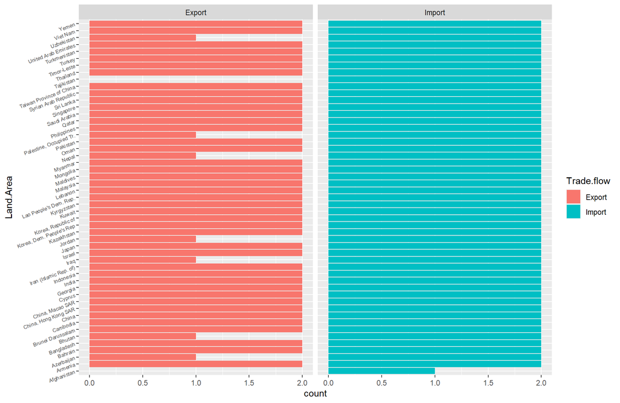

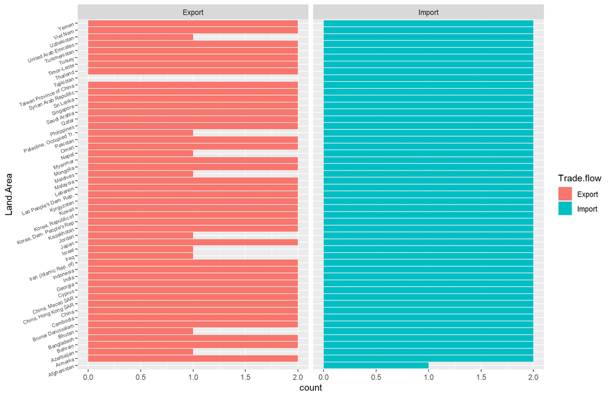